# RQA & Trajectory Analysis: Human-Human vs. Human-AI vs. AI-AI

Visual Guide and Cross-Condition Structural Comparison

PENPAL Project

2026-08-07

# 1. Corpus Overview & Data Loading

We load the three primary dataframes produced by the PENPAL processing pipeline: - **`df_raw`** (`story_metrics.csv`): Story-level master table containing all RQA scalars, trajectory geometry metrics, decay fits, and human ratings. - **`df_lag`** (`lag_profiles.csv`): Long-format decay profiles showing mean cosine similarity at each sentence distance lag $k$. - **`df_sentence_index`** (`sentence_index.csv`): Sentence-level index mapping every sentence text string and word count to its story position.

```r
df_raw <- load_story_metrics()
df_lag <- load_lag_profiles()
df_sentence_index <- load_sentence_index()

df_raw %>%
  group_by(condition) %>%
  summarise(
    Stories = n_distinct(story_id),
    `Mean Sentences` = round(mean(n_sentences, na.rm = TRUE), 1),
    `Mean Words` = round(mean(n_words, na.rm = TRUE), 1),
    .groups = "drop"
  ) %>%
  knitr::kable(caption = "Corpus Breakdown by Condition")
```

Corpus Breakdown by Condition

| condition | Stories | Mean Sentences | Mean Words |
| --- | --- | --- | --- |
| HH | 36 | 38.0 | 528.0 |
| H-LLM | 96 | 27.9 | 479.2 |
| LLM-LLM | 80 | 26.3 | 559.2 |

# 2. Visual Anatomy of Recurrence Quantification Analysis (RQA)

To intuitively understand how RQA works, imagine representing a story as an $N \times N$ matrix grid where both the rows and columns are the sentences $S_1, S_2, \dots, S_N$ in story order.

- **Main Diagonal / Theiler Band (Gray)**: Excludes trivial self-matches ($S_i \text{ with } S_i$) and optionally adjacent sentences.
- **Diagonal Lines (Green)**: Consecutive sentence pairs that recur in sequence order ($S_i \rightarrow S_{i+1}$ matches $S_j \rightarrow S_{j+1}$). This measures **Determinism (`DET`)** — i.e., echoed narrative arcs.
- **Vertical Lines (Orange)**: A single sentence matching consecutive sentences ($S_i$ matches $S_j, S_{j+1}, S_{j+2}$). This measures **Laminarity (`LAM`)** and **Trapping Time (`TT`)** — i.e., thematic stasis or dwelling on one idea.
- **Isolated Points (Blue)**: One-off semantic matches that do not form continuous sequences.

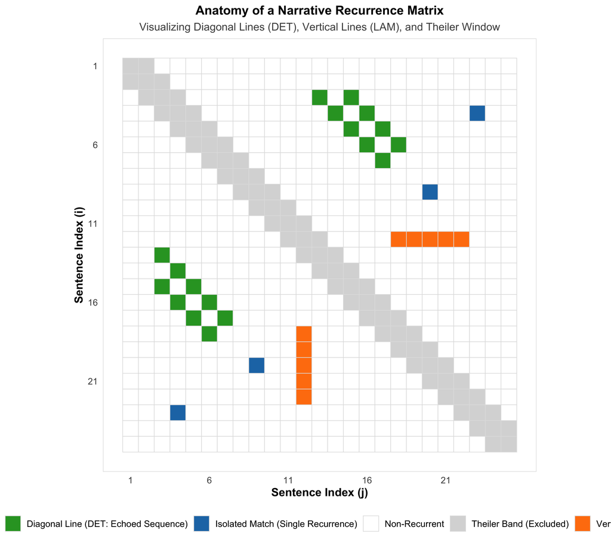

Conceptual Diagram of a Binary Recurrence Matrix (RQA)

```r
set.seed(42)
N <- 25
matrix_grid <- expand.grid(i = 1:N, j = 1:N) %>%
  mutate(
    type = "Non-Recurrent",
    # Main diagonal / Theiler band (theiler = 1)
    is_theiler = abs(i - j) <= 1
  )

# Add synthetic diagonal lines (Narrative Echoes)
matrix_grid <- matrix_grid %>%
  mutate(
    is_diag1 = (i >= 3 & i <= 7 & j == i + 10) | (j >= 3 & j <= 7 & i == j + 10),
    is_diag2 = (i >= 15 & i <= 18 & j == i - 12) | (j >= 15 & j <= 18 & i == j - 12),
    # Vertical line (Thematic Stasis / Dwelling)
    is_vert = (i == 12 & j >= 18 & j <= 22) | (j == 12 & i >= 18 & i <= 22),
    # Isolated matches
    is_iso = (i == 4 & j == 23) | (i == 23 & j == 4) | (i == 9 & j == 20) | (i == 20 & j == 9)
  ) %>%
  mutate(
    type = case_when(
      is_theiler ~ "Theiler Band (Excluded)",
      is_diag1 | is_diag2 ~ "Diagonal Line (DET: Echoed Sequence)",
      is_vert ~ "Vertical Line (LAM: Thematic Stasis)",
      is_iso ~ "Isolated Match (Single Recurrence)",
      TRUE ~ "Non-Recurrent"
    )
  )

color_scale <- c(
  "Theiler Band (Excluded)" = "#d9d9d9",
  "Diagonal Line (DET: Echoed Sequence)" = "#2ca02c",
  "Vertical Line (LAM: Thematic Stasis)" = "#ff7f0e",
  "Isolated Match (Single Recurrence)" = "#1f77b4",
  "Non-Recurrent" = "#ffffff"
)

ggplot(matrix_grid, aes(x = j, y = i, fill = type)) +
  geom_tile(color = "#e0e0e0", linewidth = 0.3) +
  scale_fill_manual(values = color_scale) +
  scale_y_reverse(breaks = seq(1, N, 5)) +
  scale_x_continuous(breaks = seq(1, N, 5)) +
  coord_fixed() +
  labs(
    title = "Anatomy of a Narrative Recurrence Matrix",
    subtitle = "Visualizing Diagonal Lines (DET), Vertical Lines (LAM), and Theiler Window",
    x = "Sentence Index (j)",
    y = "Sentence Index (i)",
    fill = "Matrix Cell Category"
  ) +
  theme_comparison(base_size = 12) +
  theme(
    legend.position = "bottom",
    legend.box = "vertical",
    panel.grid = element_blank()
  )
```

# 3. Fixed-RR vs. Fixed-Epsilon Thresholding

[figure not shown]

Comparing Recurrence Rate Distributions under Fixed-Epsilon vs Fixed-RR

```r
p1 <- ggplot(df_raw, aes(x = condition, y = eps_RR, fill = condition)) +
  geom_violin(alpha = 0.5, color = "black") +
  geom_boxplot(width = 0.2, outlier.shape = NA, alpha = 0.8) +
  geom_jitter(width = 0.1, alpha = 0.3, size = 1.5) +
  scale_fill_manual(values = condition_colors) +
  labs(
    title = "Fixed-Epsilon (eps_RR)",
    subtitle = "Raw recurrence varies widely by condition",
    y = "Recurrence Rate (eps_RR)",
    x = "Condition"
  ) +
  theme_comparison() +
  theme(legend.position = "none")

p2 <- ggplot(df_raw, aes(x = condition, y = rr_RR, fill = condition)) +
  geom_violin(alpha = 0.5, color = "black") +
  geom_boxplot(width = 0.2, outlier.shape = NA, alpha = 0.8) +
  geom_jitter(width = 0.1, alpha = 0.3, size = 1.5) +
  scale_fill_manual(values = condition_colors) +
  labs(
    title = "Fixed-RR (rr_RR)",
    subtitle = "Anchored at target RR (0.05) to compare structure fairly",
    y = "Recurrence Rate (rr_RR)",
    x = "Condition"
  ) +
  theme_comparison() +
  theme(legend.position = "none")

p1 + p2
```

# 4. Cross-Condition Structural Comparison

We compare the three conditions (**Human-Human**, **Human-AI**, **AI-AI**) across key RQA metrics (`rr_DET`, `rr_LAM`, `rr_ENTR`) and Trajectory metrics (`straightness`, `radius_gyration`).

```r
p_det <- plot_metric_boxplots(df_raw, "rr_DET", title = "Determinism (rr_DET)", ylab = "Determinism (Share in Diagonals)")
p_lam <- plot_metric_boxplots(df_raw, "rr_LAM", title = "Laminarity (rr_LAM)", ylab = "Laminarity (Share in Verticals)")
p_entr <- plot_metric_boxplots(df_raw, "rr_ENTR", title = "Diagonal Entropy (rr_ENTR)", ylab = "Entropy (Bits)")
p_ratio <- plot_metric_boxplots(df_raw, "rr_RATIO", title = "DET/RR Ratio (rr_RATIO)", ylab = "Ratio")

(p_det + p_lam) / (p_entr + p_ratio)
```

[figure not shown]

RQA Structural Metrics across Conditions

### Trajectory & Geometry Comparison

- **`straightness`**: Measures whether the story progresses directly toward a destination ($1.0$) or wanders/loops back ($\approx 0.0$).
- **`radius_gyration`**: Total semantic volume occupied by the story in embedding space.
- **`mean_step`**: Average step distance between consecutive sentences (narrative pacing/jumpiness).

```r
p_str <- plot_metric_boxplots(df_raw, "straightness", title = "Trajectory Straightness", ylab = "Straightness [0, 1]")
p_rad <- plot_metric_boxplots(df_raw, "radius_gyration", title = "Radius of Gyration", ylab = "Semantic Volume (RMS Radius)")
p_step <- plot_metric_boxplots(df_raw, "mean_step", title = "Mean Step Distance", ylab = "Mean Consecutive Step Size")
p_circ <- plot_metric_boxplots(df_raw, "circularity", title = "Story Circularity", ylab = "Opening vs Ending Cosine Sim")

(p_str + p_rad) / (p_step + p_circ)
```

[figure not shown]

Trajectory Geometry Metrics across Conditions

# 5. Semantic Decay Profiles (`df_lag`)

The long-format **`df_lag`** dataframe tracks mean cosine similarity as a function of sentence distance $k$. Fast decay indicates rapid thematic drift; slow decay with a higher floor indicates persistent global topic cohesion.

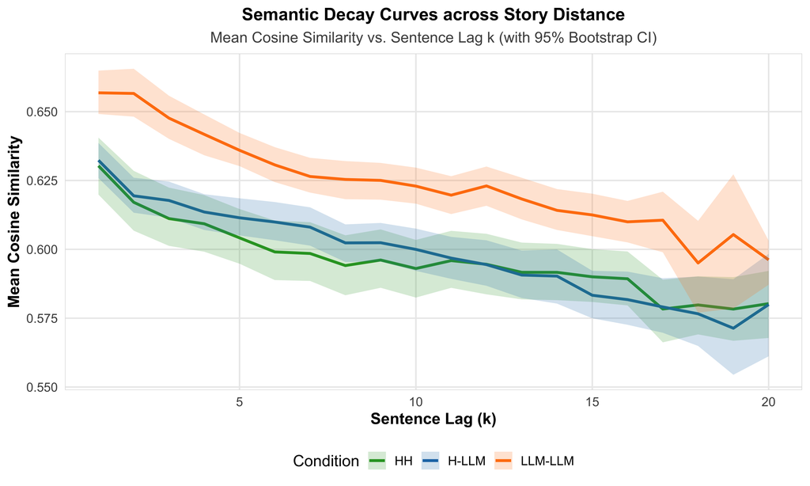

Empirical Semantic Decay Profiles by Condition

```r
ggplot(df_lag %>% filter(lag <= 20), aes(x = lag, y = mean_sim, color = condition, fill = condition)) +
  stat_summary(fun = mean, geom = "line", linewidth = 1.2) +
  stat_summary(fun.data = mean_cl_boot, geom = "ribbon", alpha = 0.2, color = NA) +
  scale_color_manual(values = condition_colors) +
  scale_fill_manual(values = condition_colors) +
  labs(
    title = "Semantic Decay Curves across Story Distance",
    subtitle = "Mean Cosine Similarity vs. Sentence Lag k (with 95% Bootstrap CI)",
    x = "Sentence Lag (k)",
    y = "Mean Cosine Similarity",
    color = "Condition",
    fill = "Condition"
  ) +
  theme_comparison()
```

# 6. Connecting Structural Metrics to Human Quality Ratings

Finally, we examine how computed structural metrics predict human ratings of **Creativity** and **Coherence**.

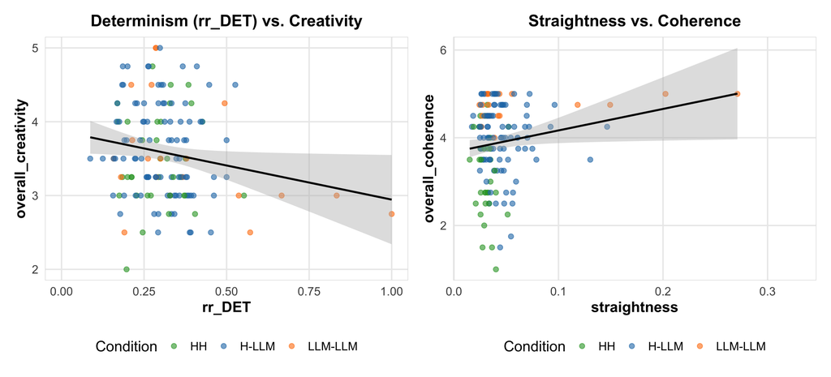

Structural Metrics predicting Human Creativity & Coherence

```r
c1 <- plot_metric_correlations(
  df_raw,
  metric_col = "rr_DET",
  rating_col = "overall_creativity",
  title = "Determinism (rr_DET) vs. Creativity"
)

c2 <- plot_metric_correlations(
  df_raw,
  metric_col = "straightness",
  rating_col = "overall_coherence",
  title = "Straightness vs. Coherence"
)

c1 + c2
```

# 7. Summary Table of Key Findings

```r
summarize_all_metrics(
  df_raw,
  metrics_vector = c("rr_DET", "rr_LAM", "rr_ENTR", "straightness", "radius_gyration", "overall_creativity", "overall_coherence")
) %>%
  select(metric, condition, n, mean, sd, ci_lower, ci_upper) %>%
  mutate(across(where(is.numeric), ~ round(.x, 3))) %>%
  knitr::kable(caption = "Condition Means and 95% CIs for Primary Metrics")
```

Condition Means and 95% CIs for Primary Metrics

| metric | condition | n | mean | sd | ci_lower | ci_upper |
| --- | --- | --- | --- | --- | --- | --- |
| rr_DET | HH | 36 | 0.297 | 0.086 | 0.269 | 0.326 |
| rr_DET | H-LLM | 96 | 0.300 | 0.093 | 0.281 | 0.319 |
| rr_DET | LLM-LLM | 80 | 0.322 | 0.188 | 0.281 | 0.363 |
| rr_LAM | HH | 36 | 0.421 | 0.065 | 0.400 | 0.442 |
| rr_LAM | H-LLM | 96 | 0.401 | 0.089 | 0.383 | 0.419 |
| rr_LAM | LLM-LLM | 80 | 0.382 | 0.136 | 0.353 | 0.412 |
| rr_ENTR | HH | 36 | 0.768 | 0.362 | 0.650 | 0.887 |
| rr_ENTR | H-LLM | 96 | 0.528 | 0.443 | 0.439 | 0.617 |
| rr_ENTR | LLM-LLM | 74 | 0.638 | 0.459 | 0.533 | 0.743 |
| straightness | HH | 36 | 0.031 | 0.008 | 0.028 | 0.033 |
| straightness | H-LLM | 96 | 0.045 | 0.021 | 0.041 | 0.050 |
| straightness | LLM-LLM | 80 | 0.065 | 0.068 | 0.050 | 0.080 |
| radius_gyration | HH | 36 | 0.626 | 0.025 | 0.617 | 0.634 |
| radius_gyration | H-LLM | 96 | 0.615 | 0.027 | 0.609 | 0.620 |
| radius_gyration | LLM-LLM | 80 | 0.581 | 0.042 | 0.572 | 0.590 |
| overall_creativity | HH | 36 | 3.465 | 0.619 | 3.263 | 3.667 |
| overall_creativity | H-LLM | 91 | 3.637 | 0.637 | 3.506 | 3.768 |
| overall_creativity | LLM-LLM | 20 | 3.525 | 0.756 | 3.194 | 3.856 |
| overall_coherence | HH | 36 | 3.222 | 0.929 | 2.919 | 3.526 |
| overall_coherence | H-LLM | 91 | 3.981 | 0.764 | 3.824 | 4.138 |
| overall_coherence | LLM-LLM | 20 | 4.725 | 0.291 | 4.597 | 4.853 |